# R Notebook

**UNIVERSIDAD DE INGENIERÍA Y TECNOLOGÍA**

## **El consumo de bebidas energéticas por estudiantes de la UTEC en Lima en el 2022**

### 1. Introducción

**1.1. Relevancia:**

El tema propuesto principalmente se enfoca en la comparación del rendimiento académico de los estudiantes encuestados de la Universidad de Ingeniería y Tecnología que consumen bebidas energéticas y los que no las consumen durante el ciclo universitario. Es de relevancia para el público porque permite identificar cuán útil o dañino puede ser el consumo de estas bebidas para la salud, además de ello, permite evaluar las consecuencias que le genera a los alumnos la cantidad de trabajos, proyectos, tareas, en su desarrollo físico y mental. La información que obtengamos nos servirá como base al plantear tanto propuestas para los silabos académicos como bebidas alternativas. Por otro lado, finalizando esta investigación, establecer la conexión que tiene el consumo de bebidas energéticas con la horas de sueño y estudio de un estudiante, su desempeño en el ámbito académico y deportivo, y los efectos que pueden traer en su cuerpo de manera negativa, permite generar un poco más de conciencia sobre el consumo excesivo de este producto.

**1.2. Objetivos:**

- **Objetivos principales:**
  - Determinar si el consumo de bebidas energéticas influye en el rendimiento académico de los estudiantes universitarios encuestados en la UTEC.
  - Examinar la frecuencia de consumo frente a las diferentes circunstancias y efectos que pueden ocasionar las bebidas energéticas.
- **Objetivos secundarios:**

  Encontrar una relación entre:
  - El promedio ponderado de los estudiantes y las horas utilizadas para estudiar.
  - Los estudiantes que consumen o no bebidas energéticas y sus promedios ponderados.
  - El consumo de bebidas energéticas y los efectos secundarios que ocasiona en la salud de los estudiantes.
  - El consumo de bebidas energéticas y el ciclo universitario que están cursando los estudiantes.
  - Las circunstancias bajo las que los estudiantes consumen bebidas energéticas y cuán necesarias son consideradas durante el periodo universitario.

**1.3. Investigación:**

Consideramos un total de 3 estudios relacionados al tema del consumo de las bebidas energéticas en los estudiantes y sus efectos, encontramos que su metodología se basa en la obtención de datos a través de encuestas realizadas con unos parámetros similares a los nuestros como la frecuencia de consumo, el género, la edad, la realización de actividad física, el motivo de consumo, marca de bebida que suele comprar y efectos del consumo. Nuestra encuesta maneja variables enfocadas en esa dirección, lo que indica que estas podrán cumplir con los objetivos planteados, al igual que los datos en cada observación.

Según el primer estudio tenemos que los estudiantes de medicina “suelen tomar bebidas energéticas con frecuencia, en especial los hombres y lo hacen principalmente para mantenerse despiertos para estudiar” (Baladia Eduard, 2019), termina con una idea sobre concienciar el consumo de estas bebidas que pueden ser dañinas; el segundo estudio llega a una conclusión similar ya que señala “(…), si bien la mayor parte no las consume de forma regular. El consumo de bebidas energéticas se incrementan en época de exámenes” (Universidad de La Laguna, 2013) e igualmente buscan dejar un mensaje sobre lo que ocasiona el abuso de estas bebidas; por último, el tercer estudio no tiene un área en su publicación donde hablan específicamente sobre una conclusión, pero sí muestra una discusión sobre el tema donde empieza a relacionar al grupo selecto de estudiantes con los resultados obtenidos para el final “(..), generar estrategias en beneficio de este grupo de estudiantes con miras a crear conciencia sobre los riesgos que conlleva el perder el horizonte de lo que significa alcanzar y mantener unos hábitos de consumo saludables de manera que contribuyan a un buen estado de salud” (Fajardo et al, 2018).

### 2. Datos

**2.1. Recolección de datos:**

Para la recolección de datos se empleó una encuesta dividida en dos secciones, la primera para almacenar los aspectos generales, esta abarca información personal y sobre su vida universitaria; y la segunda para almacenar los aspectos específicos centrados en el tema, esta consta netamente de preguntas sobre efectos, consecuencias y preferencias del consumidor. El enlace de la encuesta mencionada fue compartido repetidas veces con los estudiantes de la universidad por correo electrónico y a través de las demás aplicaciones que permiten llegar al público objetivo, elegimos esta estrategia porque tiene un gran alcance y se realiza virtualmente. Luego de una semana, dado que no logramos alcanzar la cantidad de observaciones necesarias, la encuesta fue realizada de manera presencial hasta cumplir con la meta. Es importante precisar que para el estudio se necesita que un 80% de la muestra sí consuma bebidas energéticas y el 20% restante no.

**2.2. Población, muestra y muestreo:**

Los alumnos de la Universidad de Ingeniería y Tecnología son considerados como la población de estudio y un grupo de 225 estudiantes (hasta ahora) extraídos de la población ha sido seleccionado como muestra. Realizamos un muestreo no probabilístico por conveniencia, ya que seleccionamos la muestra de manera que sean accesibles para la recolección de datos, teniendo en cuenta a estudiantes que consumen bebidas energéticas.

**2.3. Variables:**

| **Variable** | **Tipo** | **Restricciones** |
| --- | --- | --- |
| Género | Categórica nominal | Femenino, Masculino |
| Edad | Numérica discreta | Entero positivo |
| Carrera | Categórica nominal | Ingeniería Ambiental, Ingeniería Civil, Ingeniería Química, Ingeniería Electrónica, Ingeniería de la Energía, Ingeniería Mecánica, Ingeniería Mecatrónica, Ciencia de la computación, Ciencia de datos, … |
| Ciclo | Categórica ordinal | Primer, segundo, tercer, cuarto, quinto, sexto, séptimo, octavo, noveno y décimo |
| Promedio | Numérica continua | Número positivo entre 5 y 20 con decimales |
| Horas de estudio | Numérica continua | Número positivo entre 1 y 8 con decimales* |
| Horas de sueño | Numérica continua | Número positivo entre 4 y 8 con decimales* |
| Deporte | Categórica nominal | Sí, No |
| Días de práctica | Numérica discreta | Entero positivo entre 0 y 7 |
| Consumo | Categórica nominal | Sí, No |
| Rendimiento | Categórica ordinal | Nada, poco, regular, mucho |
| Frecuencia | Categórica ordinal | Nada, poco, regular, mucho |
| Necesidad | Categórica ordinal | Nada, poco, regular, mucho |
| Marca 1 | Categórica nominal | Red bull, monster, volt, otro |
| Marca 2 | Categórica nominal | Red bull, monster, volt, otro |
| Efectos secundarios | Categórica nominal | Taquicardia, ansiedad, gastritis, insomnio, cansancio, otro. |
| Momento | Categórica nominal | Mañana, tarde, noche |
| Circunstancias | Categórica nominal | Exámenes, tareas y proyectos, ejercicio, sin razón, otra. |

**2.4. Limpieza de base de datos:**

Para limpiar la base de datos dividimos en dos partes el proceso, primero variables y luego observaciones. Editamos los nombres de las variables extraídas del cuestionario con el comando “rename”, y seguido a ello, eliminamos la primera fila del cuadro que no es parte del estudio. Cada variable por separado fue analizada con el comando “unique” para después modificarla con el comando “mutate” y la función “ifelse”. Repetimos el procedimiento con las variables Carrera, Deporte, Días de practica, Consumo y Momento. En el caso del Promedio, utilizamos la función “as.numeric” para que pase de categórica a numérica. Por último, reemplazamos todos los espacios vacíos por NA con el comando “mutate” y la función “ifelse”. La revisión de las observaciones fue minuciosa, en este el principal objetivo es que todos los datos por fila tengan coherencia entre sí. Ejecutado el código, se puede considerar que la base de datos final está limpia. Tanto las variables como observaciones están escritas y asignadas correctamente según lo planteado en la tabla. La información obtenida podrá servir sin ningún inconveniente durante el análisis descriptivo.

### 3. Análisis descriptivo

**Variables relevantes:** Promedio, Consumo, Horas de estudio, Horas de sueño, Circunstancias, Efectos secundarios, Ciclo universitario, Frecuencia.

**Descriptores de la variable “Horas de estudio”:**

```
## Media: 4.9
```

```
## Mediana: 5
```

```
## Desviación Estándar: 1.44
```

```
## Rango: 1 8
```

```
## Coeficiente de Variación (%): 29.4
```

```
##    Min. 1st Qu.  Median    Mean 3rd Qu.    Max.
##   1.000   4.200   5.000   4.902   6.000   8.000
```

**Descriptores de la variable “Horas de sueño”:**

```
## Media: 6.54
```

```
## Mediana: 7
```

```
## Desviación Estándar: 0.88
```

```
## Rango: 4 8
```

```
## Coeficiente de Variación (%): 13.49
```

```
##    Min. 1st Qu.  Median    Mean 3rd Qu.    Max.
##    4.00    6.00    7.00    6.54    7.10    8.00
```

**Descriptor gráfico de la variable “Promedio”:**

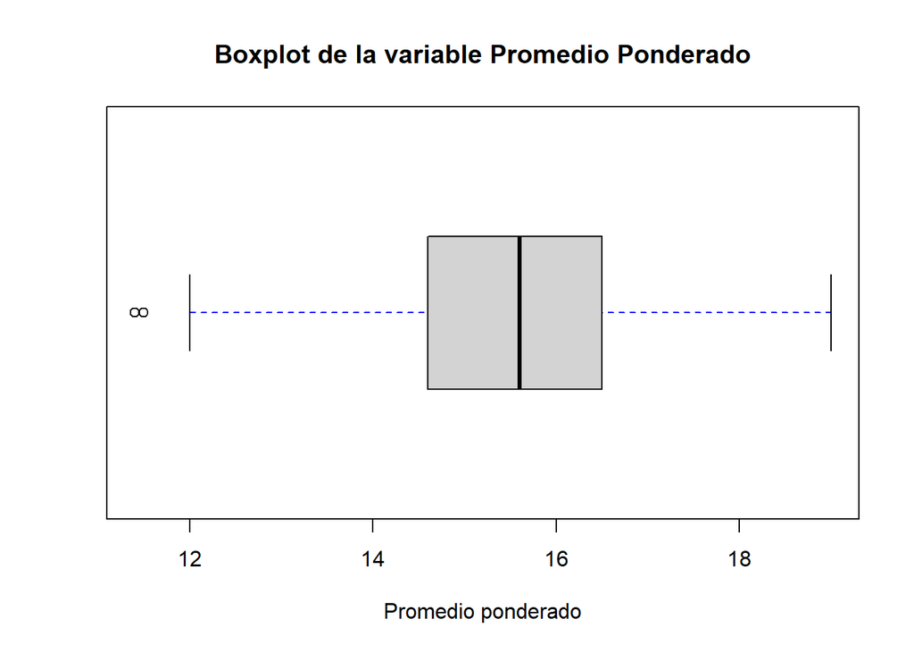

**Recodificar la variable “Promedio” y relacionar con cantidad de estudiantes que consumen y no consumen bebidas energéticas:**

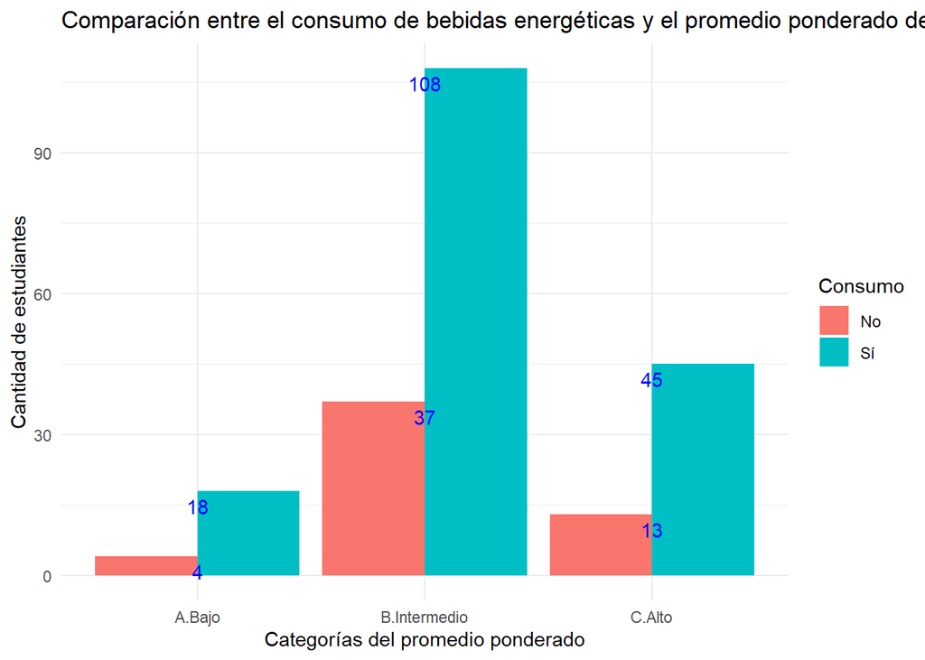

**Recodificar la variable “Promedio” y relacionar con cantidad de estudiantes que practican y no deportes:**

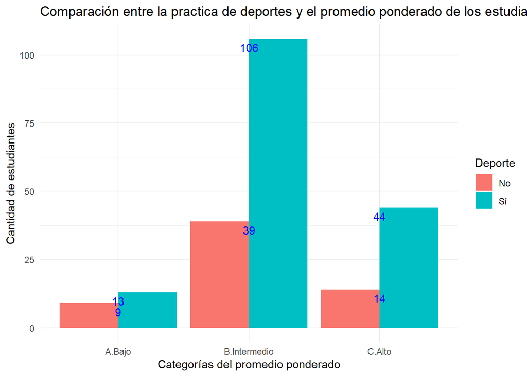

Se estableció una comparación con la variable numérica Promedio y la variable categórica Deporte, la primera fue recodificada como una variable categórica, es decir, se establecieron rangos, si la nota estaba entre 0 a 13.49 sería bajo, si estaba entre 13.5 y 16.49 sería intermedio y de 16.5 a 20 sería alto. En primer lugar, al evaluar las barras correspondientes se observa que, teniendo un total de 145 estudiantes con un promedio intermedio, el 73.1% de este grupo practica algún deporte y mantiene un buen rendimiento académico; en los dos casos restantes son similares a la mencionada, tanto para los 58 estudiantes con un promedio alto (75.86%) como para los 22 estudiantes con uno bajo (59.09%). Se puede observar que la mayoría de estudiantes encuestados con buen promedio (intermedio o alto) practican algún deporte y consumen bebidas energéticas.

**Relación entre la variable “Horas de estudio” y la variable “Promedio” de los estudiantes encuestados:**

[figure not shown]

Se esperan los resultados mostrados, debido a que las personas absorben el aprendizaje de manera diferente y el tiempo que cada uno utiliza para este fin no es el mismo. Razón por la cual existe un margen de error con los valores que hemos obtenido en las encuestas para la variable horas de estudio, ya que aparecen los puntos de manera esparcida y sin ninguna relación.

# Análisis probabilístico

### Distribuciones

**1. Distribución Hipergeométrica:**

De la muestra total de 225 encuestados, extraemos sin reemplazo a 15, sabiendo que 92 estudiantes opinaron que su rendimiento mejoró “mucho”. **¿Cuál será la probabilidad de que máximo 5 de ellos hayan respondido “mucho”?**

X: Opinión sobre la influencia en el rendimiento académico cuando consumes bebidas energéticas. Y: Número de encuestados que tuvieron mucha influencia en su rendimiento académico. Y tiene H(N=225, M=92, n=15) $\rightarrow P(Y<=5)$ **Respuesta:** La probabilidad es de 0.3708998

```
## [1] 0.3708998
```

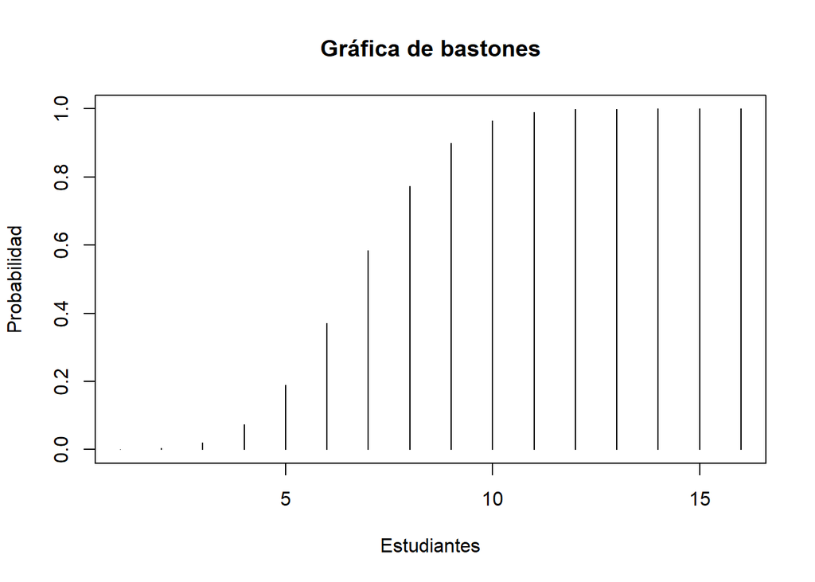

**2. Distribución Binomial**

X: Número de encuestados que consume bebidas energéticas cuando estudia para un examen. X tiene B(x=2,n=10,p=0.2311111) $\rightarrow P(X\geq 2)=1-P(X\leq 1)$ **Respuesta:** La probabilidad es de 0.710717

```
## [1] 0.710717
```

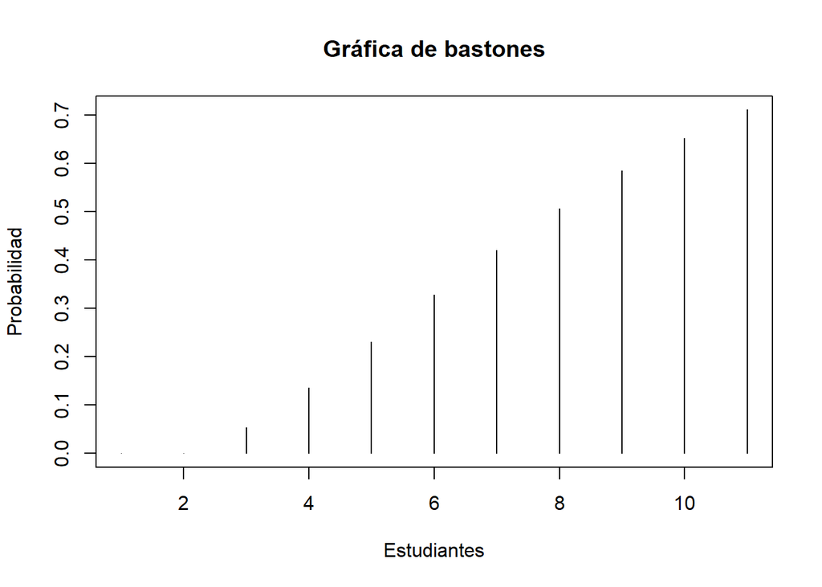

**3. Distribución Normal**

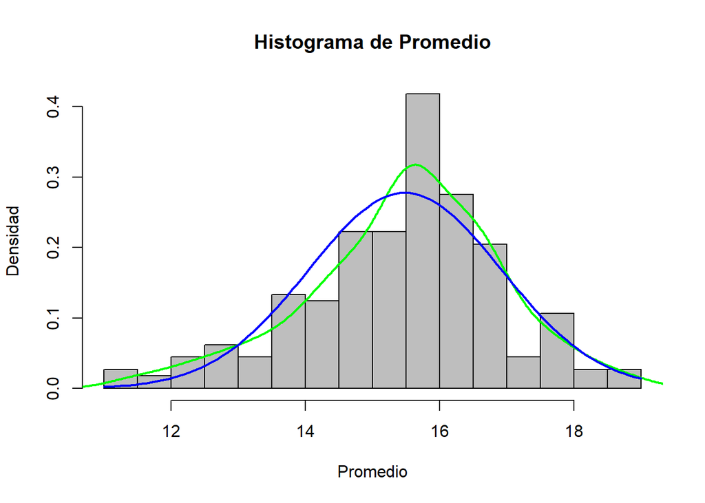

**4. Distribución Exponencial:**

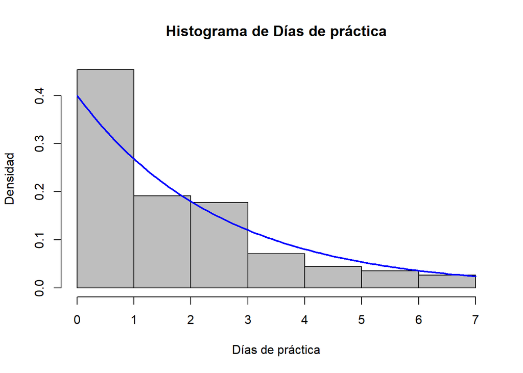

### Tablas cruzadas

**1. Tabla cruzada entre las variables “Consumo” y “Promedio”:**

1. ¿Cuál es la probabilidad de que los estudiantes con promedio “alto”, sí consuman bebidas energéticas? Axioma 1: $P(X)=\frac{45}{171}=0.2631579$
2. ¿Cuál es la probabilidad de que los estudiantes no consuman bebidas energéticas? Axioma 2: $P(X^c)=1-P(X)=1-\frac{171}{225}=0.24$
3. ¿Cuál es la probabilidad de que los estudiantes con promedio “intermedio” o “bajo”, no consuman bebidas energéticas? Axioma 4: $P(X_1\cup X_2)\cap P(X_3)=(P(X_1)+P(X_2))*P(X_3)=(\frac{37}{54}+\frac{4}{54})*\frac{54}{225} =0.1822222$
4. ¿Cuál es la probabilidad de que todos los estudiantes encuestados no tengan un promedio “alto” ni “bajo”? Axioma 7: $P(X_1^c\cap X_2^c)=P(X_1\cap X_2)^c=1-P(X_1\cup X_2)=1-(\frac{58}{225}+\frac{22}{225})=0.6444444$

**2. Tabla cruzada entre las variables “Carrera” y “Promedio”:**

1. ¿Cuál es la probabilidad que los estudiantes de ingeniería ambiental tengan promedio alto e intermedio? Axioma 10: $P(X_1\cap X_2\cap X_3)=P(X_1)*P(X_2)*P(X_3)=\frac{14}{37}*\frac{19}{37}*\frac{37}{225}=0.03195195$
2. ¿Cuál es la probabilidad que los estudiantes tengan promedio bajo, sabiendo que son de la carrera ingeniería civil? Axioma 9: $P(X_1/X_2)=\frac{P(X_1\cap X_2)}{P(X_2)}=\frac{\frac{8}{225}}{\frac{22}{225}}=\frac{8}{22}=0.3636364$
3. ¿Cuál es la probabilidad que los estudiantes no tengan promedio intermedio o sean de la carrera ingeniería industrial? Axioma 8: $P(X_1^c\cup X_2^c)=P(X_1\cup X_2)^c=1-P(X_1\cap X_2)=1-\frac{19}{225}=0.9155556$
4. ¿Cuál es la probabilidad que un estudiante no sea de la carrera ingeniería mecánica pero si tenga un promedio alto? Axioma 6: $P(X_1^c\cap X_2)=P(X_2)-P(X_1\cap X_2)=\frac{58}{225}-\frac{4}{225}=0.24$

**Bibliografía:**

- F. (2018). Consumo de bebidas energizantes en una población de escolares de Bogotá, Colombia. Scielo Salud Pública. https://www.scielosp.org/article/rsap/2018.v20n5/579-583/
- Universidad de La Laguna. (2018). Consumo de bebidas energizantes en universitarios. Rev Esp Nutr Comunitaria. https://www.renc.es/imagenes/auxiliar/files/Rev%20Esp%20Nutr%20Comunitaria%202013_4-3.pdf
- Baladia, E. (2018). Prevalencia del consumo de bebidas energéticas, motivación y factores asociados en alumnos de Medicina: estudio transversal. Scielo. https://scielo.isciii.es/scielo.php?script=sci_arttext&pid=S2174-51452020000100007
- Hernández, A. D. S. C. N. D. M. (2016). Distribuciones de probabilidad en R. Introducción a R. https://estadistica-dma.ulpgc.es/cursoR4ULPGC/10-distribProbabilidad.html
- Bellosta, G. C. J. (2018, 22 abril). R para profesionales de los datos: una introducción. dataanalytics. https://datanalytics.com/libro_r/graficos-basicos.html

[Encuesta en google forms](https://docs.google.com/forms/d/15EmVO0ScaHdU717Fq4qExSk0F3o45SMJD1J8M-h6t0Y/edit?usp=sharing)